# Prosper Loan Analysis

Luca Miniati

## Background

Prosper is a peer-to-peer lending platform where borrowers can find investors to fund their loans. Prosper’s business relies on the idea of fractionalization, where funds for loans are essentially “crowd sourced” from investors, who can invest as little as $25 per loan.

I will be analyzing the performance of Prosper loans from 2023-2024. The dataset is availble at https://help.prosper.com/hc/en-us/articles/210013083-Where-can-I-download-data-about-loans-through-Prosper with a free account.

For the subsequent analysis, it’s important to define some terms.

- Peer-to-peer lending: A system that connects borrowers directly to investors, cutting out banks from the process.
- Default: If a borrower fails to pay back a loan, the loan is considered “defaulted”. The borrower’s credit score is impacted, and the investors are not compensated for their loss.
- Completion: If a borrower pays the loan back in full, the loan is considered “completed”.
- Charge-off: If a borrower fails to pay multiple payments on a loan, the financial institution that created the loan is likely to write the loan off as a loss, essentially expecting it to default. Borrower still technicaly owes the money, but the debt might be sold to a new buyer or transferred to a collection agency.
- Charge-off recovery: In the event of a charge-off, the borrower still has a chance to repay the loan. If they do, the loan is considered “recovered”.
- Status: The current status of a loan (e.g “Defaulted”, “Completed”, etc.).
- Amount: The amount of money the borrower takes from the investors.
- Term: How long the borrower has to repay the amount.
- Annual Interest Rate (APR): The interest rate that is charged to the borrower each year. All Prosper loans are [amortized](https://www.investopedia.com/terms/a/amortized_loan.asp).

## Tidying

```r
df <- read.csv("data/data.csv")

nrow(df[duplicated(df), ])
```

```
## [1] 0
```

At a first glance, Prosper processed 135809 unique loans in 2023, tracking 22 columns of data with no duplicate rows.

```r
# Check for null values
colSums(is.na(df))
```

```
##                     loan_number                 amount_borrowed                   borrower_rate
##                               0                               0                               0
##                  prosper_rating                            term                   age_in_months
##                               0                               0                               0
##                origination_date                   days_past_due               principal_balance
##                               0                               0                               0
##               service_fees_paid                  principal_paid                   interest_paid
##                               0                               0                               0
##               prosper_fees_paid                  late_fees_paid     debt_sale_proceeds_received
##                               0                               0                               0
##                     loan_status         loan_status_description             loan_default_reason
##                               0                               0                          135621
## loan_default_reason_description           next_payment_due_date         next_payment_due_amount
##                               0                               0                               0
##         co_borrower_application
##                               0
```

In the dataset, it looks like there aren’t any null values except in the `loan_default_reason` column, which has an unusally high number of null values (135621 values out of the 135809 total rows). This is because only a fraction of the loans are actually defaulted; the rest are current (in progress) or completed (without default). These other loans don’t have a default reason in the table because they aren’t defaulted.

```r
# Selecting the loans that have a non-null default reason
loans_with_default_reason <- df[!is.na(df$loan_default_reason), ]
head(loans_with_default_reason)
```

```
##      loan_number amount_borrowed borrower_rate prosper_rating term age_in_months
## 256      2069280           15500        0.1123              A   48            10
## 426      2004839           15000        0.2240              C   36            14
## 780      2034641            9500        0.2580              E   60            12
## 1097     2005205           14000        0.2750              E   60            14
## 1468     2048986           15000        0.0600             AA   24            12
## 1984     2037535           11500        0.3016              E   60            12
##         origination_date days_past_due principal_balance service_fees_paid principal_paid
## 256  2023-05-01 00:00:00           122          14462.55            -50.93        1037.45
## 426  2023-01-06 00:00:00           122          12798.63            -81.72        2201.37
## 780  2023-03-02 00:00:00           126           9181.46            -10.35         318.54
## 1097 2023-01-06 00:00:00           122          13157.07            -85.18         842.93
## 1468 2023-03-23 00:00:00            78          10201.67            -93.21        4798.33
## 1984 2023-03-01 00:00:00           122          10976.78            -61.16         523.22
##      interest_paid prosper_fees_paid late_fees_paid debt_sale_proceeds_received loan_status
```

[output cut: 20 more lines]

In the results of the loans with a default reason, there are some rows with `loan_default_reason_description=DECEASED`. If someone passed away with an active loan, their loan was marked as defaulted. From a financial standpoint, this makes sense, because a death would be considered a financial loss by the investor who gave them money Because of this, we won’t impute or drop these null value; rather, we’ll treat the missing values as meaningful in indicating non-defaulted loans.

```r
# Check data types of each column
sapply(df, class)
```

```
##                     loan_number                 amount_borrowed                   borrower_rate
##                       "integer"                       "numeric"                       "numeric"
##                  prosper_rating                            term                   age_in_months
##                     "character"                       "integer"                       "integer"
##                origination_date                   days_past_due               principal_balance
##                     "character"                       "integer"                       "numeric"
##               service_fees_paid                  principal_paid                   interest_paid
##                       "numeric"                       "numeric"                       "numeric"
##               prosper_fees_paid                  late_fees_paid     debt_sale_proceeds_received
##                       "numeric"                       "numeric"                       "numeric"
##                     loan_status         loan_status_description             loan_default_reason
##                       "integer"                     "character"                       "integer"
## loan_default_reason_description           next_payment_due_date         next_payment_due_amount
##                     "character"                     "character"                       "numeric"
##         co_borrower_application
##                     "character"
```

The data types look mostly correct, with the exception of `origination_date` and `prosper_rating`.

```r
df$origination_date <- as.POSIXct(df$origination_date)
df$prosper_rating <- as.factor(df$prosper_rating)
```

For easier manipulation of dates, `origination_date` was converted into a POSIXct object. Additionally, `prosper_rating` was converted to a factor to simplify the categorical analysis later.

```r
# Summary statistics for numeric variables
summary(df[, sapply(df, is.numeric)])
```

```
##   loan_number      amount_borrowed borrower_rate         term       age_in_months
##  Min.   :2001986   Min.   : 2000   Min.   :0.0600   Min.   :24.00   Min.   : 3.000
##  1st Qu.:2044575   1st Qu.: 7500   1st Qu.:0.1281   1st Qu.:36.00   1st Qu.: 6.000
##  Median :2083501   Median :12000   Median :0.1656   Median :48.00   Median : 9.000
##  Mean   :2084009   Mean   :14162   Mean   :0.1825   Mean   :48.91   Mean   : 8.971
##  3rd Qu.:2123366   3rd Qu.:19500   3rd Qu.:0.2350   3rd Qu.:60.00   3rd Qu.:12.000
##  Max.   :2167288   Max.   :50000   Max.   :0.3300   Max.   :60.00   Max.   :14.000
##
##  days_past_due     principal_balance service_fees_paid principal_paid    interest_paid
##  Min.   :  0.000   Min.   :    0     Min.   :-575.37   Min.   :    0.0   Min.   :   0.0
##  1st Qu.:  0.000   1st Qu.: 4621     1st Qu.:-117.57   1st Qu.:  677.4   1st Qu.: 519.8
##  Median :  0.000   Median : 9408     Median : -64.69   Median : 1413.0   Median :1047.1
##  Mean   :  6.686   Mean   :11041     Mean   : -87.13   Mean   : 3080.0   Mean   :1404.9
##  3rd Qu.:  0.000   3rd Qu.:15809     3rd Qu.: -32.52   3rd Qu.: 3000.0   3rd Qu.:1951.2
##  Max.   :355.000   Max.   :49398     Max.   :   0.00   Max.   :50000.0   Max.   :8849.7
##
##  prosper_fees_paid late_fees_paid    debt_sale_proceeds_received  loan_status
##  Min.   :  0.000   Min.   :  0.000   Min.   :0                   Min.   :1.000
##  1st Qu.:  0.000   1st Qu.:  0.000   1st Qu.:0                   1st Qu.:1.000
##  Median :  0.000   Median :  0.000   Median :0                   Median :1.000
##  Mean   :  2.136   Mean   :  1.196   Mean   :0                   Mean   :1.371
##  3rd Qu.:  0.000   3rd Qu.:  0.000   3rd Qu.:0                   3rd Qu.:1.000
##  Max.   :315.000   Max.   :395.940   Max.   :0                   Max.   :6.000
##
##  loan_default_reason next_payment_due_amount
##  Min.   :2.00        Min.   :   0.0
##  1st Qu.:2.00        1st Qu.: 140.1
##  Median :2.50        Median : 304.3
##  Mean   :2.71        Mean   : 340.0
##  3rd Qu.:3.00        3rd Qu.: 493.3
##  Max.   :6.00        Max.   :1486.6
##  NA's   :135621
```

```r
df <- subset(df, select = -c(loan_number, loan_default_reason_description))
```

With our data tidy, we can move on.

## Exploratory Data Analysis

First, let’s have an overview of the numeric features of the dataset.

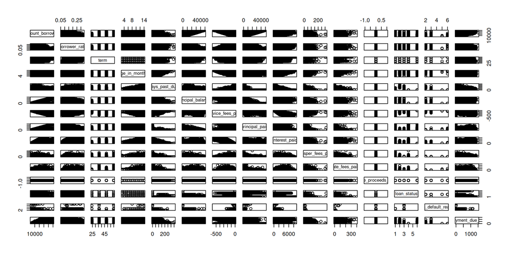

```r
pairs(df[, sapply(df, is.numeric)])
```

From a birds-eye view, there seems to be slight relationships between some variables, but the data is mostly scattered.

Next, I’d like to explore the aforementioned outliers.

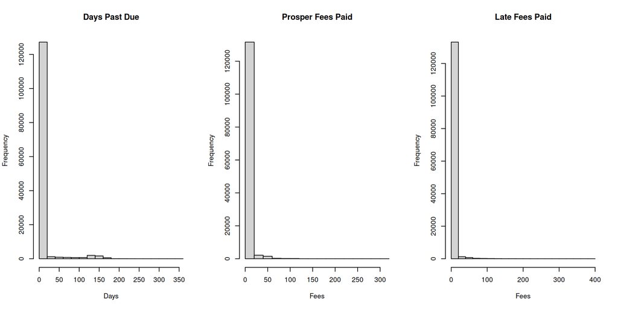

```r
# Histograms
par(mfrow=c(1,3))
hist(df$days_past_due, main="Days Past Due", xlab="Days")
hist(df$prosper_fees_paid, main="Prosper Fees Paid", xlab="Fees")
hist(df$late_fees_paid, main="Late Fees Paid", xlab="Fees")
```

Most people pay back their loans on time, with some extreme outliers.

Prosper rates each individual borrower based on their credit, income, and past delinquencies. This metric is used to grade borrowers on trustworthiness. This `prosper_rating` is a crucial field for determining which loans are funded by investors, as it is blatantly displayed on the listings for each loan on the Prosper website.

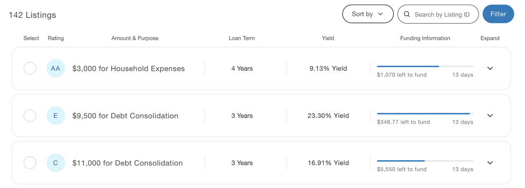

Prosper Investor Website

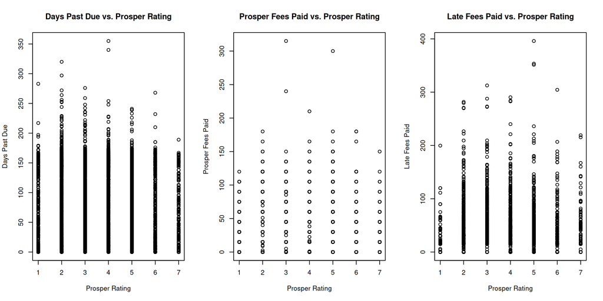

```r
# Map `prosper_rating` to numberic values
ratings_numeric <- c("HR" = 1, "E" = 2, "D" = 3, "C" = 4, "B" = 5, "A" = 6, "AA" = 7)

# Convert prosper_rating to numeric using the mapping
df$prosper_rating_numeric <- ratings_numeric[as.character(df$prosper_rating)]

# Scatter plots
par(mfrow=c(1, 3))
plot(df$prosper_rating_numeric, df$days_past_due, main="Days Past Due vs. Prosper Rating", xlab="Prosper Rating", ylab="Days Past Due")
plot(df$prosper_rating_numeric, df$prosper_fees_paid, main="Prosper Fees Paid vs. Prosper Rating", xlab="Prosper Rating", ylab="Prosper Fees Paid")
plot(df$prosper_rating_numeric, df$late_fees_paid, main="Late Fees Paid vs. Prosper Rating", xlab="Prosper Rating", ylab="Late Fees Paid")
```

```r
# Check the correlation
cor(df$prosper_rating_numeric, df$days_past_due)
```

```
## [1] -0.1422459
```

```r
cor(df$prosper_rating_numeric, df$prosper_fees_paid)
```

```
## [1] -0.09271193
```

```r
cor(df$prosper_rating_numeric, df$late_fees_paid)
```

```
## [1] -0.06299032
```

It looks like their rating wasn’t able to capture the volatile nature of peer-to-peer loan payments. Let’s see if it was able to predict loan status.

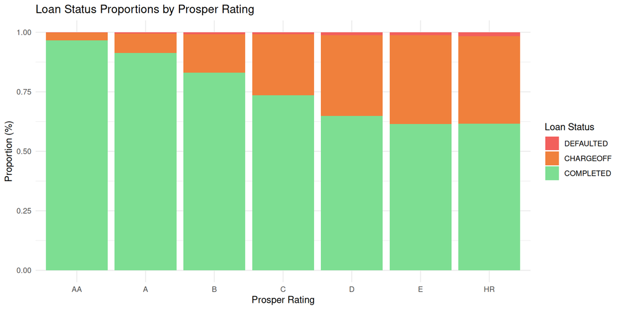

```r
# Filter the dataframe to include only final loan statuses (non-current loans)
df_filtered <- df[df$loan_status_description %in% c("DEFAULTED", "COMPLETED", "CHARGEOFF"), ]

# Calculate proportions of loan status by `prosper_rating`
loan_status_proportions <- prop.table(table(df_filtered$prosper_rating, df_filtered$loan_status_description),
                                      margin = 1)
# Convert to dataframe for plotting
loan_status_df <- as.data.frame(loan_status_proportions)

# Set data in correct order
loan_status_df <- loan_status_df %>%
    mutate(Var1 = factor(Var1, levels = c("AA", "A", "B", "C", "D", "E", "HR")),
           Var2 = factor(Var2, levels = c("DEFAULTED", "CHARGEOFF", "COMPLETED")))

# Plot stacked bar chart
ggplot(loan_status_df, aes(x = Var1, y = Freq, fill = Var2)) +
  geom_bar(stat = "identity") +
  scale_fill_manual(values = c("DEFAULTED" = "#F25F5C", "CHARGEOFF" = "#F0803C", "COMPLETED" = "#7DDE92")) +
  labs(x = "Prosper Rating", y = "Proportion (%)", fill = "Loan Status") +
  ggtitle("Loan Status Proportions by Prosper Rating") +
  theme_minimal()
```

While `prosper_rating` doesn’t predict late payments well, it does seem to be a good predictor for the final status of a loan. This makes sense because investors are likely to care less about when they get paid, and more about whether they get their money back at all in the long run.

Peer-to-peer lending gets a bad rap because of its historical instability and high default rates. Let’s investigate Prosper’s default rates in this dataset further.

```r
# Sort by `DEFAULTED` in descending order
loan_status_proportions <- loan_status_proportions[order(loan_status_proportions[, "DEFAULTED"]), ]
round(loan_status_proportions, digits = 4)
```

```
##
##      CHARGEOFF COMPLETED DEFAULTED
##   AA    0.0315    0.9668    0.0017
##   A     0.0824    0.9127    0.0049
##   C     0.2569    0.7352    0.0078
##   B     0.1610    0.8311    0.0080
##   E     0.3728    0.6149    0.0123
##   D     0.3391    0.6486    0.0123
##   HR    0.3667    0.6167    0.0167
```

As expected, higher `prosper_rating` generally corresponds to a lower default rate. However, with the criteria of default rate, `C` loans actually outperformed `B` loans and `E` loans outperformed `D` loans. Let’s investigate this further, since this isn’t what we expected.

Taking a closer look, the discrepancy lies in the `CHARGEOFF` column. `C` loans have ~10% higher rates of charge-off than those of `B` loans, which causes the shockingly low default rate. Remember, loans that are charged off are likely to default. Prosper probably separates the rates of charge-off and default in order to artificially deflate the default rate. Compared to the market average default rate of greater than 10% [[1]](https://jfin-swufe.springeropen.com/articles/10.1186/s40854-020-00197-y), all of Prosper’s default rates in 2023 were techically less than 1.7%, without factoring in charge-offs. The true default rate is much higher if we consider charge-offs.

To consider charge-offs in the total default rate for each rating, we can use Prosper’s reported recovery rate of 9.5% ± 2.5% [[2]](https://help.prosper.com/hc/en-us/articles/210013613-What-happens-if-a-borrower-misses-a-payment#:~:text=If%20a%20loan%20is%20more,range%20from%207%2D12%25.).

```r
# Adjust for charge-offs
loan_status_proportions_adjusted <- data.frame(
    COMPLETED_LO = loan_status_proportions[, "COMPLETED"] +
        0.07 * loan_status_proportions[, "CHARGEOFF"],
    COMPLETED_MID = loan_status_proportions[, "COMPLETED"] +
        0.095 * loan_status_proportions[, "CHARGEOFF"],
    COMPLETED_HI = loan_status_proportions[, "COMPLETED"] +
        0.12 * loan_status_proportions[, "CHARGEOFF"],
    DEFAULTED_LO = loan_status_proportions[, "DEFAULTED"] +
        0.93 * loan_status_proportions[, "CHARGEOFF"],
    DEFAULTED_MID = loan_status_proportions[, "DEFAULTED"] +
        0.905 * loan_status_proportions[, "CHARGEOFF"],
    DEFAULTED_HI = loan_status_proportions[, "DEFAULTED"] +
        0.88 * loan_status_proportions[, "CHARGEOFF"]
)
# Sort by `DEFAULTED_HI` ascending
loan_status_proportions_adjusted <- loan_status_proportions_adjusted[
                            order(loan_status_proportions_adjusted$DEFAULTED_HI), ]
round(loan_status_proportions_adjusted, digits = 4)
```

```
##    COMPLETED_LO COMPLETED_MID COMPLETED_HI DEFAULTED_LO DEFAULTED_MID DEFAULTED_HI
## AA       0.9690        0.9698       0.9706       0.0310        0.0302       0.0294
## A        0.9185        0.9205       0.9226       0.0815        0.0795       0.0774
## B        0.8423        0.8463       0.8504       0.1577        0.1537       0.1496
## C        0.7532        0.7596       0.7661       0.2468        0.2404       0.2339
## D        0.6723        0.6808       0.6893       0.3277        0.3192       0.3107
## HR       0.6423        0.6515       0.6607       0.3577        0.3485       0.3393
## E        0.6410        0.6503       0.6596       0.3590        0.3497       0.3404
```

Adjusting for charge-offs, the data now show that `HR` loans outperform `E` loans, but all the other ratings are in order.

```r
# Group by Prosper rating
rating_groups <- split(df$borrower_rate, df$prosper_rating)

# Compute mean
average_rates <- tapply(df$borrower_rate, df$prosper_rating, mean)
# Sort by rate, descendin
(average_rates <- average_rates[order(average_rates, decreasing = TRUE)])
```

```
##         HR          E          D          C          B          A         AA
## 0.31236935 0.28090543 0.23137211 0.19349508 0.14649011 0.12347916 0.09878159
```

`HR` loans actually get higher interest rates, even though they default less often than `E` loans. From this standpoint, `HR` loans coulrd represent a unique opportunity for investing. For investors, this suggests a possible strategy of “barbell investing”. This investment strategy offers a balance between safety and potential for higher returns.

By investing mainly in low-risk loans (`AA-B`) and allocating a portion of the portfolio to high-risk (`HR`) loans, investors can create a barbell-shaped portfolio. This strategy aims to capture the benefits of both low-risk and high-risk investments, allowing investors to potentially earn higher returns while still mitigating risk through diversification.

## Conclusion

Through EDA, many insights were found about the Prosper peer-to-peer lending platform. Most notable was the analysis of the true default rate across ratings. After accounting for charge-offs, the strategy of “barbell investing” appears to be an attractive option to maximize returns.

In the future, I’d like to explore the performance of different investment strategies through a backtest (likely written in Python). Additionally, it would be interesting to see more columns of data, to see if I could “reverse-engineer” Prosper’s rating system.